# Cardio Good Fitness

## Background:

Cardio Good Fitness, a retail store wants to build a customer profile for treadmill products in its offering. There is a set of data that has been collected from the customers of the retail store. The ask is to extracting insights from data that will assist in targeting new customers

## Objective:

1. Build up a customer profile for different products of Cardio Good Fitness.
2. Suggest insights and recommendations that will help the company in targeting new customers.

## Questions:

- What are the different factors that influence customers towards a particular product offering?
- What are the key recommendations, to get new customers?

## Data Description:

1. Product - the model no. of the treadmill
2. Age - in no of years, of the customer
3. Gender - of the customer
4. Education - in no. of years, of the customer
5. Marital Status - of the customer
6. Usage - Avg. # times the customer wants to use the treadmill every week
7. Fitness - Self rated fitness score of the customer (5 - very fit, 1 - very unfit)
8. Income - of the customer
9. Miles- expected to run

### Import needed python libraries - pandas, numpy, seaborn, matplotlib.pyplot

```python
# Libraries to help with reading and manipulating data
import pandas as pd
import numpy as np
import matplotlib.pyplot as plt

# Libraries to help with data visualization
import seaborn as sns
import matplotlib.pyplot as plt
%matplotlib inline
sns.set(style="darkgrid")

# Library to generates profile reports from a pandas DataFrame
import pandas_profiling

#supress warnings on depreceated features
import warnings
warnings.filterwarnings("ignore")
```

### Read the dataset

```python
data = pd.read_csv('CardioGoodFitness.csv')
```

```python
# copyy original data to another variable to avoid accidental changes to original data
df = data.copy()
```

### View the head of data

```python
# looking at first 10 observations
df.head(10)
```

|  | Product | Age | Gender | Education | MaritalStatus | Usage | Fitness | Income | Miles |
| --- | --- | --- | --- | --- | --- | --- | --- | --- | --- |
| 0 | TM195 | 18 | Male | 14 | Single | 3 | 4 | 29562 | 112 |
| 1 | TM195 | 19 | Male | 15 | Single | 2 | 3 | 31836 | 75 |
| 2 | TM195 | 19 | Female | 14 | Partnered | 4 | 3 | 30699 | 66 |
| 3 | TM195 | 19 | Male | 12 | Single | 3 | 3 | 32973 | 85 |
| 4 | TM195 | 20 | Male | 13 | Partnered | 4 | 2 | 35247 | 47 |
| 5 | TM195 | 20 | Female | 14 | Partnered | 3 | 3 | 32973 | 66 |
| 6 | TM195 | 21 | Female | 14 | Partnered | 3 | 3 | 35247 | 75 |
| 7 | TM195 | 21 | Male | 13 | Single | 3 | 3 | 32973 | 85 |
| 8 | TM195 | 21 | Male | 15 | Single | 5 | 4 | 35247 | 141 |
| 9 | TM195 | 21 | Female | 15 | Partnered | 2 | 3 | 37521 | 85 |

**Observations from the data**

- Gender and MaritialStatus are descriptive of nature
- Age is also a descriptive data , but Gender and MaritialStatus can be categorical

### Check the shape of the dataset

```python
df.shape
```

```
(180, 9)
```

- The dataset has 180 rows and 9 columns.

#### Check for any missing data

```python
#check for missing data
df.isna().sum()
```

```
Product          0
Age              0
Gender           0
Education        0
MaritalStatus    0
Usage            0
Fitness          0
Income           0
Miles            0
dtype: int64
```

- There are no missing data, all the data rows have value for all the columns

#### check the info of the data

```python
df.info()
```

```
<class 'pandas.core.frame.DataFrame'>
RangeIndex: 180 entries, 0 to 179
Data columns (total 9 columns):
 #   Column         Non-Null Count  Dtype
---  ------         --------------  -----
 0   Product        180 non-null    object
 1   Age            180 non-null    int64
 2   Gender         180 non-null    object
 3   Education      180 non-null    int64
 4   MaritalStatus  180 non-null    object
 5   Usage          180 non-null    int64
 6   Fitness        180 non-null    int64
 7   Income         180 non-null    int64
 8   Miles          180 non-null    int64
dtypes: int64(6), object(3)
memory usage: 12.8+ KB
```

- Gender and MaritalStatus are not of categorical datatype. There are 6 numberic columns and 3 non Numeric columns.
- Gender, MaritalStatus and Prodcut can be converted to be categorical datatype

# Data Preprocessing

```python
# Corrrect the datatypes for Gender, MaritalStatus and Prodcut
#  Gender, MaritalStatus and Prodcut should be converted to categorical type
df['Gender'] = df.Gender.astype('category')
df['MaritalStatus'] = df.MaritalStatus.astype('category')
df['Product'] = df.Product.astype('category')
```

```python
df.info()
```

```
<class 'pandas.core.frame.DataFrame'>
RangeIndex: 180 entries, 0 to 179
Data columns (total 9 columns):
 #   Column         Non-Null Count  Dtype
---  ------         --------------  -----
 0   Product        180 non-null    category
 1   Age            180 non-null    int64
 2   Gender         180 non-null    category
 3   Education      180 non-null    int64
 4   MaritalStatus  180 non-null    category
 5   Usage          180 non-null    int64
 6   Fitness        180 non-null    int64
 7   Income         180 non-null    int64
 8   Miles          180 non-null    int64
dtypes: category(3), int64(6)
memory usage: 9.5 KB
```

- Product, Gender and MaritalStatus are now of categorical datatype.

### Summary of the data

```python
df.describe().T
```

|  | count | mean | std | min | 25% | 50% | 75% | max |
| --- | --- | --- | --- | --- | --- | --- | --- | --- |
| Age | 180.0 | 28.788889 | 6.943498 | 18.0 | 24.00 | 26.0 | 33.00 | 50.0 |
| Education | 180.0 | 15.572222 | 1.617055 | 12.0 | 14.00 | 16.0 | 16.00 | 21.0 |
| Usage | 180.0 | 3.455556 | 1.084797 | 2.0 | 3.00 | 3.0 | 4.00 | 7.0 |
| Fitness | 180.0 | 3.311111 | 0.958869 | 1.0 | 3.00 | 3.0 | 4.00 | 5.0 |
| Income | 180.0 | 53719.577778 | 16506.684226 | 29562.0 | 44058.75 | 50596.5 | 58668.00 | 104581.0 |
| Miles | 180.0 | 103.194444 | 51.863605 | 21.0 | 66.00 | 94.0 | 114.75 | 360.0 |

- Mean age of customer is around 29
- Average usage of the product is around 3 times a week and self rated fitness score is 3 which is in middle of ( 1 to 5 , 5 being very fit)
- There are some outliers in Age and most of the customers are between 24 and 33 years old
- Income and Miles have outliers, as the difference between 3rd quartile and maximum value is big and Standard deviation on this columns are also big.

**Checking the summary of non-numeric variables.**

```python
# default of  describe() is to show only summary of numeric variables
df.describe(exclude='number').T
```

|  | count | unique | top | freq |
| --- | --- | --- | --- | --- |
| Product | 180 | 3 | TM195 | 80 |
| Gender | 180 | 2 | Male | 104 |
| MaritalStatus | 180 | 2 | Partnered | 107 |

- The data set has three different prodcuts

#### Let's check the count of each unique category in each of the categorical variables.

```python
#Make a list of all catrgorical columns
cat_cols=['Product', 'Gender', 'MaritalStatus']

#Printing number of count of each unique value in each column
for column in cat_cols:
    print(df[column].value_counts())
    print('-'*30)
```

```
TM195    80
TM498    60
TM798    40
Name: Product, dtype: int64
------------------------------
Male      104
Female     76
Name: Gender, dtype: int64
------------------------------
Partnered    107
Single        73
Name: MaritalStatus, dtype: int64
------------------------------
```

- There are three unique products in the data set, most of the customers are user of product 'TM195'
- There are more male customers than female customers
- There are more customers with MaritalStatus as Partnered

### Find the mode of different columns

```python
#get mode of columns in dataframe
df.mode()
```

|  | Product | Age | Gender | Education | MaritalStatus | Usage | Fitness | Income | Miles |
| --- | --- | --- | --- | --- | --- | --- | --- | --- | --- |
| 0 | TM195 | 25 | Male | 16 | Partnered | 3 | 3 | 45480 | 85 |

- Most customers use product 'TM195'
- The average profile of the customer is aged 25, Male and who rate themselves of decent fitness level(3)

# Exploratory Data Analysis

### Numerical values exploration

- Define a custom fuction for univariate analysis of numerical values

```python
# import the library for labelling
import matplotlib.patheffects as path_effects

def add_median_labels(ax):
    lines = ax.get_lines()
    # determine number of lines per box (this varies with/without fliers)
    boxes = [c for c in ax.get_children() if type(c).__name__ == 'PathPatch']
    lines_per_box = int(len(lines) / len(boxes))
    # iterate over median lines
    for median in lines[4:len(lines):lines_per_box]:
        # display median value at center of median line
        x, y = (data.mean() for data in median.get_data())
        # choose value depending on horizontal or vertical plot orientation
        value = x if (median.get_xdata()[1]-median.get_xdata()[0]) == 0 else y
        text = ax.text(x, y, f'{value:.1f}', ha='center', va='center',
                       fontweight='bold', color='white', bbox=dict(facecolor='black'),size=15)
        # create median-colored border around white text for contrast
        text.set_path_effects([
            path_effects.Stroke(linewidth=3, foreground=median.get_color()),
            path_effects.Normal(),
        ])
```

```python
def box_and_histogram(column,  figsize=(10,10), bins = None):
    """ Boxplot and histogram together, with median labels on boxplot
    df_series: dataframe column
    figsize: size of fig (default (9,8))
    bins: number of bins (default None / auto)
    color of mean is green and median is black
    """
    f2, (ax_box2, ax_hist2) = plt.subplots(nrows = 2, # Number of rows of the subplot grid= 2
                                           sharex = True, # x-axis will be shared among all subplots
                                           gridspec_kw = {"height_ratios": (.25, .75)},
                                           figsize = figsize
                                            ) # creating the 2 subplots
    box_plot = sns.boxplot(column, ax=ax_box2,showmeans=True, color='red')
    add_median_labels(box_plot.axes)


    sns.distplot(column, kde=F, bins=bins) if bins else sns.distplot(column, kde=False, ) # For histogram
    ax_hist2.axvline(np.mean(column), color='g', linestyle='--') # Add mean to the histogram
    ax_hist2.axvline(np.median(column), color='black', linestyle='-') # Add median to the histogram
```

## Observations from Age

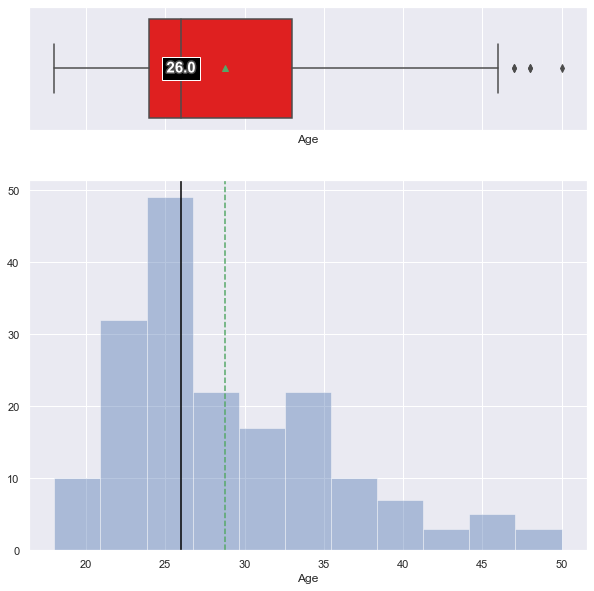

```python
box_and_histogram(df['Age']); # Box and histplot for Age
```

**Observations**

- Age has a few outlier, age above the value 46 is a ouliter and there are 3 cutomers above the outlier age.
- Average age of the customer is 29 and median value is 26.
- Age is slightly right-skewed.

## Observations from Education

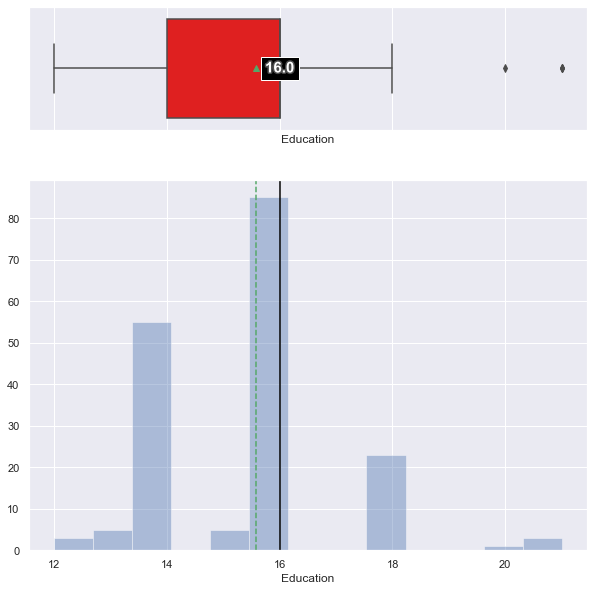

```python
box_and_histogram(df['Education']); # Box and histplot for Education
```

**Observations**

- Most customers have at least 15 year of education

## Observations from Usage

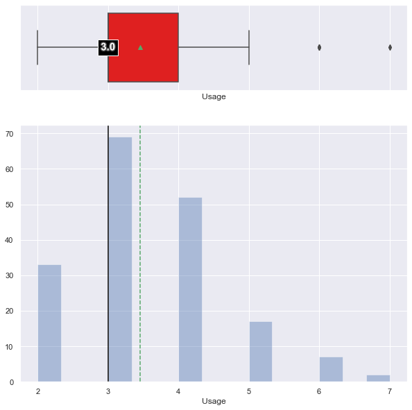

```python
box_and_histogram(df.Usage); # Box and histplot for Usage
```

**Observations**

- Most customers want to use the product between three to four times a week.

### Observations from Fitness

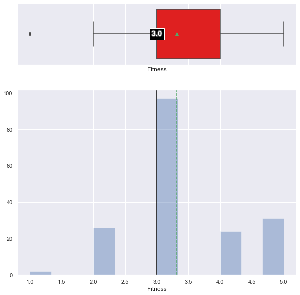

```python
box_and_histogram(df.Fitness); # Box and histplot for Fitness
```

**Observations**

- Most customers rate themselves with a fitness level of 3

### Observations from Income

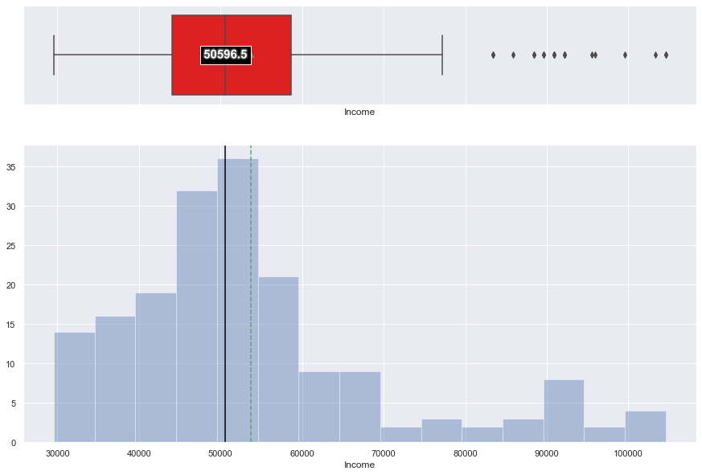

```python
box_and_histogram(df.Income, figsize=(15,10)); # Box and histplot for Income
```

**Observations**

- Most customers fall in the income range of 45,000 to 60,000 . There are about 11 outliers too.
- There is a right-skew for this variable.

## Observations from Miles

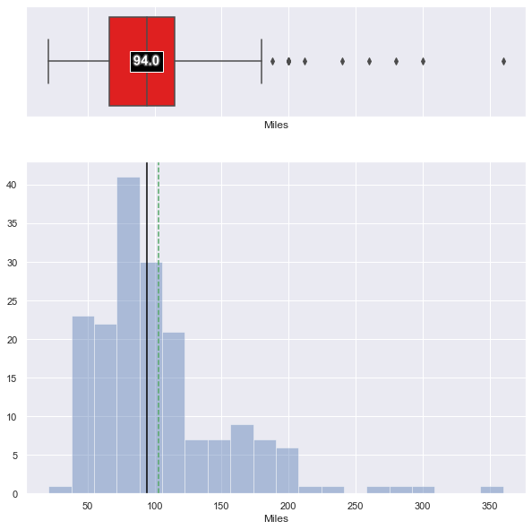

```python
box_and_histogram(df.Miles); # Box and histplot for Miles
```

**Observations**

- Most customers plan to run between 60 and 100 miles per week.
- Their primary goal appears to be fitness and not to compete in professional events.
- There is a right-skew for this variable.

### Categorical values exploration

```python
# Function to create barplots that indicate percentage for each category.
def barplot_with_percent(plot, df_series):
    '''
    plot
    df_series: dataframe column
    '''

    total = len(df_series) # length of the column
    for p in ax.patches:
        percentage = '{:.1f}%'.format(100 * p.get_height()/total) # percentage of each class of the category
        x = p.get_x() + p.get_width() / 2 - 0.05 # width of the plot
        y = p.get_y() + p.get_height()           # hieght of the plot
        ax.annotate(percentage, (x, y), size = 12) # annotate the percantage
```

## Observations on Product

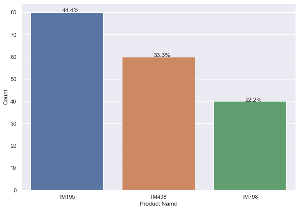

```python
plt.figure(figsize=(10,7))  # set plot size
ax = sns.countplot(df['Product'])  # seaborn count plot
plt.xlabel('Product Name')  # Add label
plt.ylabel('Count')
barplot_with_percent(ax,df['Product'])  # box lot with percentage
```

**Observations**

- Most customers have TM195 product.
- TM798 is the product which has lesser customers.

## Observations on Gender

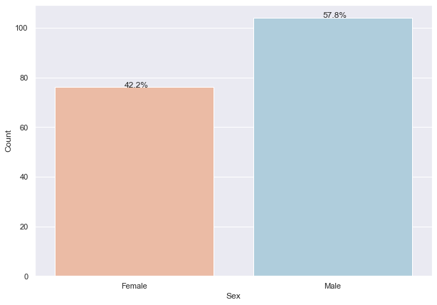

```python
plt.figure(figsize=(10,7))
ax = sns.countplot(df['Gender'],palette ='RdBu')
plt.xlabel('Sex')
plt.ylabel('Count')
barplot_with_percent(ax,df['Gender'])
```

**Observations**

- There are more male customer than female customers.

### Observations on MaritalStatus

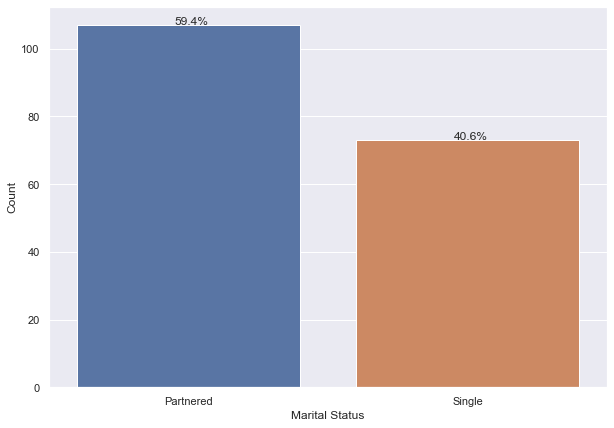

```python
plt.figure(figsize=(10,7))
ax = sns.countplot(df['MaritalStatus'])
plt.xlabel('Marital Status')
plt.ylabel('Count')
barplot_with_percent(ax,df['MaritalStatus'])
```

**Observations**

- There are more cutomers who are with Marital Status of Partnered.

## Bivariate Analysis

**Plot bivariate charts between variables to understand their interaction with each other.**

##### Correlation

```python
# Check for correlation among numerical variables
num_var = ['Age','Education','Usage','Fitness','Income', 'Miles']

corr = df[num_var].corr()
```

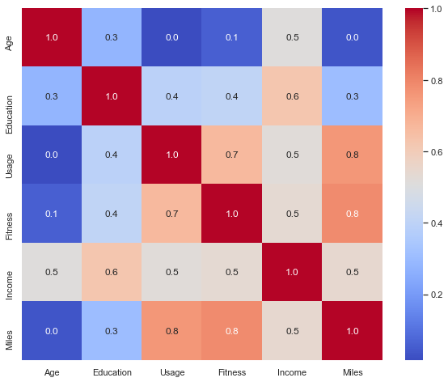

```python
plt.figure(figsize=(10,8))
# plot the heatmap
sns.heatmap(corr, annot=True,cmap='coolwarm',
        fmt=".1f",
        xticklabels=corr.columns,
        yticklabels=corr.columns);
```

**Observations**

- Usage and Miles, Miles and Fitness are corelated.

  ```
       The more the usage the more Miles are run.
       As more miles are run , the user is at a higher Fitness level.
  ```

- Understandably, Fitness and Usage have a correlation
- Important to note that correlation does not imply causation.
- There does not seem to be a strong relationship between Usage and Age.

### Scatter plot

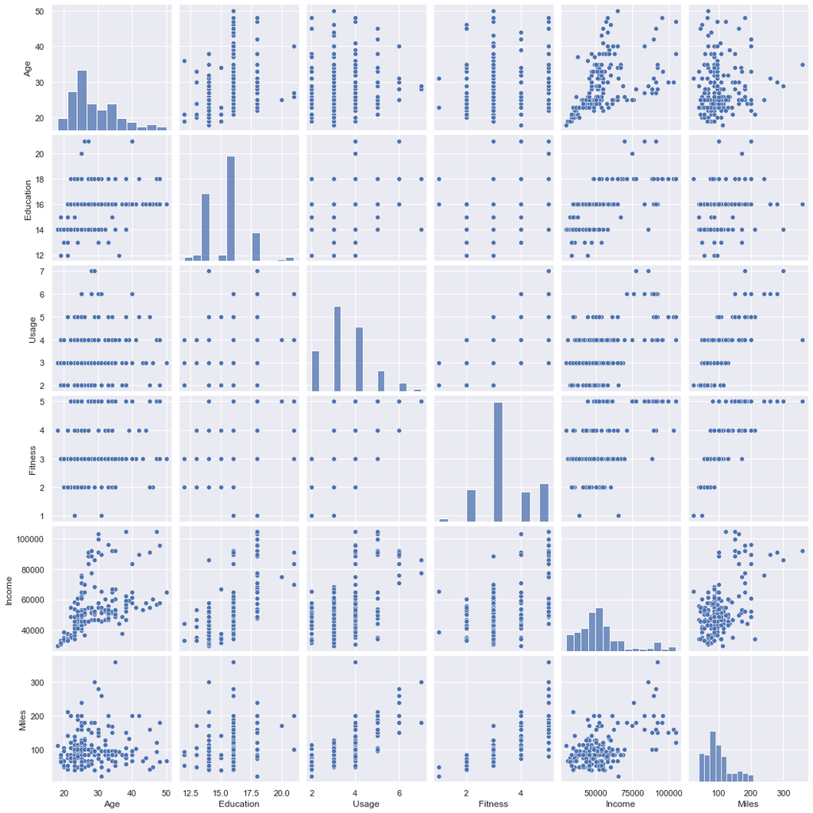

```python
sns.pairplot(df[num_var])  # Seaborn pair plot
plt.show()
```

**Observations**

- People above 40 do not run more than 200 miles.
- People who run more than 250 miles are aged less than 35.
- There does not seem to be clear relation between Age and usage or between other variables.
- As from the correlation plot , Usage does not have a strong relationship to Age, Education.
- When income is higher there is a correlation between income and usage.

### Line plot

#### Miles Run Per Week Vs Age

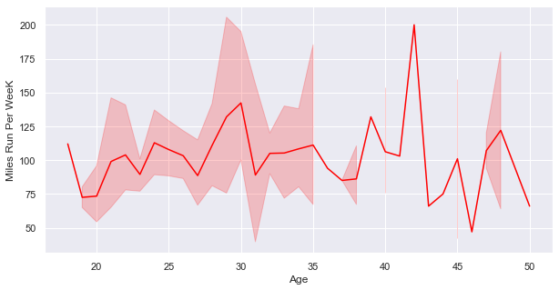

```python
plt.figure(figsize=(10,5))
sns.lineplot(x="Age", y="Miles",data=df,color="RED")
plt.ylabel('Miles Run Per WeeK')
plt.xlabel('Age')
plt.show()
```

#### Dispersion of Age

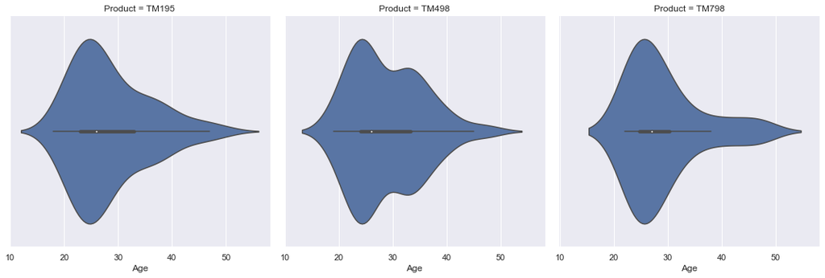

```python
# Dispersion of Age
sns.catplot(x='Age',
             col='Product',
             data=df,
             col_wrap=4,
             kind="violin");
```

**Observations**

- There is right skew for Age for all three products, which indicate customers above the median age are also interested in the product

#### Usage Per Week Vs Age

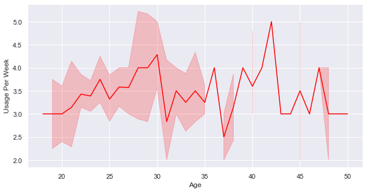

```python
plt.figure(figsize=(10,5))
sns.lineplot(x="Age", y="Usage",data=df,color="RED") # line plot
plt.ylabel('Usage Per Week')  # Add label for the axis
plt.xlabel('Age')
plt.show()
```

#### Usage across Age

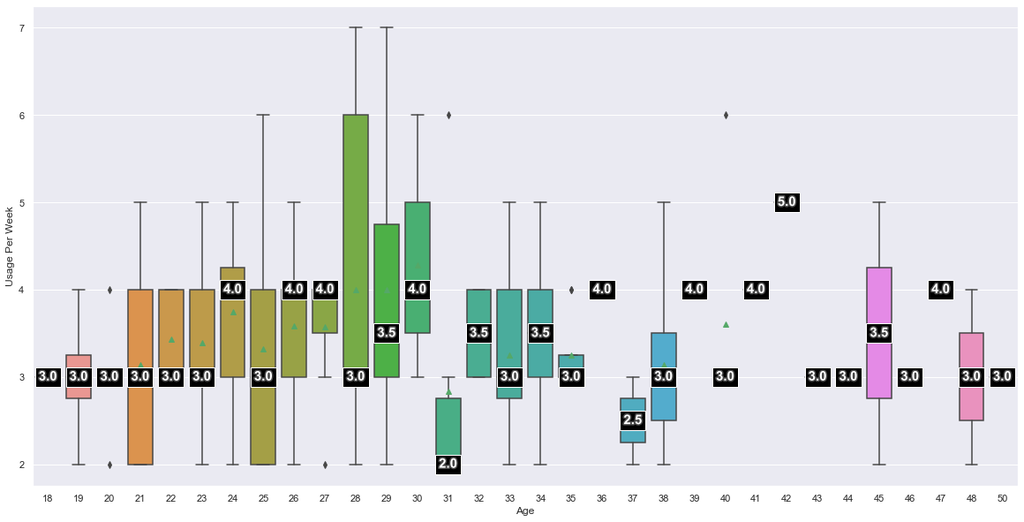

```python
plt.figure(figsize=(20,10))   # To resize the plot
box_plot = sns.boxplot(df['Age'],df['Usage'],showmeans=True)  # box plot
add_median_labels(box_plot.axes)  # Add median values to box plot
plt.ylabel('Usage Per Week')
plt.xlabel('Age')
plt.show()
```

**Observations**

- Customers with Age of 28 have largest dispersion in level of usage, indicating that this age of 28 has mixed usage level among others

### Gender Vs Usage

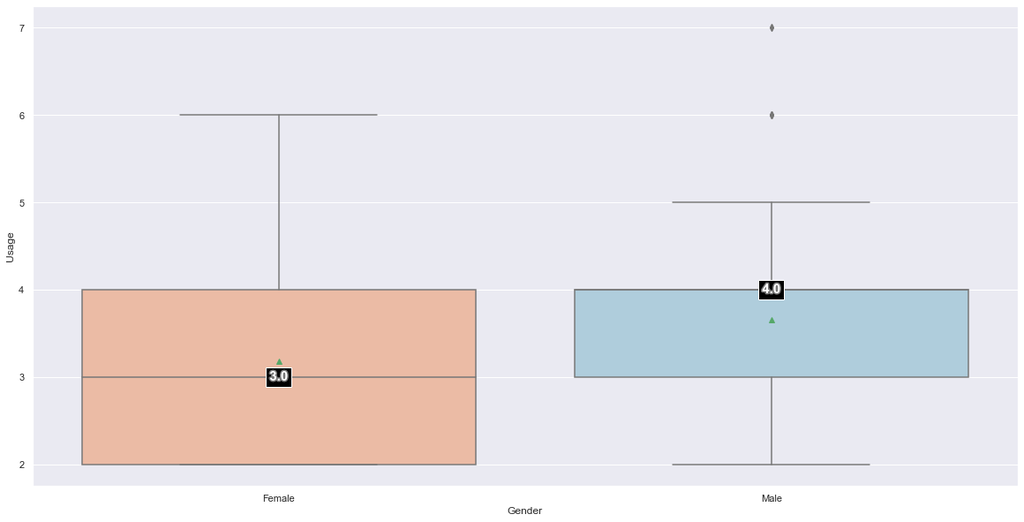

```python
plt.figure(figsize=(20,10))  # To resize the plot
box_plot = sns.boxplot(df['Gender'],df['Usage'],showmeans=True,palette ='RdBu')
add_median_labels(box_plot.axes)
plt.ylabel('Usage')
plt.xlabel('Gender')
plt.show()
```

**Observations**

- As identified Male customer have slightly higher usage per week

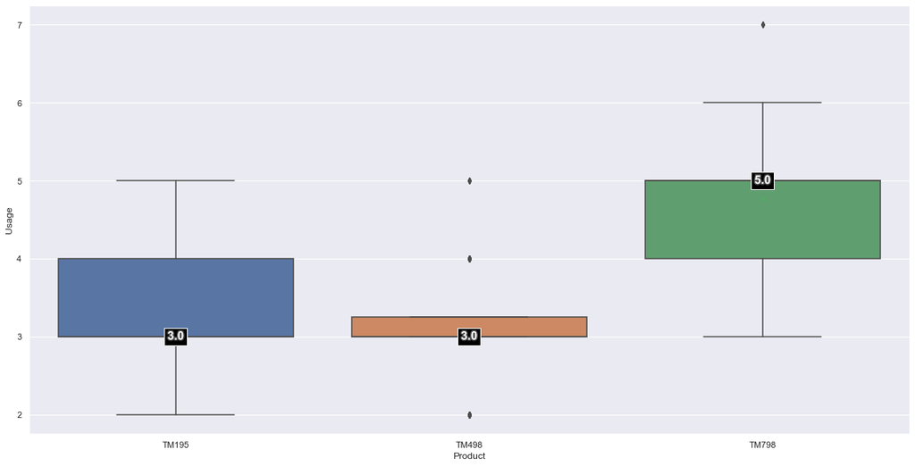

```python
plt.figure(figsize=(20,10))     # To resize the plot
box_plot = sns.boxplot(df['Product'],df['Usage'],showmeans=True)
add_median_labels(box_plot.axes)
plt.ylabel('Usage')
plt.xlabel('Product')
plt.show()
```

**Observation**

- TM798 has the highest level of usage per week.
- TM195 and TM498 have the same level of usage per week.

### Multivariate Analysis

**Usage Heatmap -Age + Income**

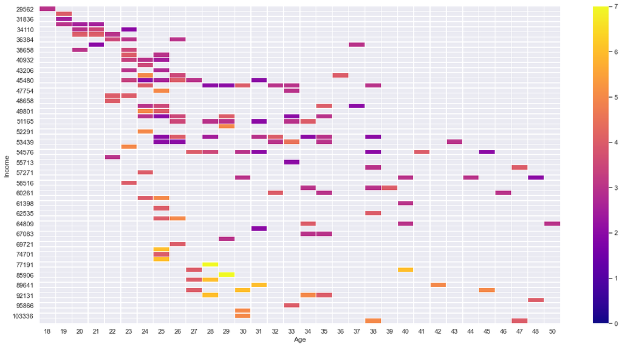

```python
df_hm =df.pivot_table(index = 'Income',columns ='Age',values ='Usage')
# Draw a heatmap
plt.figure(figsize = (20,10)) # To resize the plot
sns.heatmap(df_hm,  fmt="d", cmap='plasma', linewidths=.5, vmin=0)
plt.show()
```

**Observation**

- Income with respect to Age does not seem to have a strong relation to Usage.

**Usage Heatmap -Age + Gender**

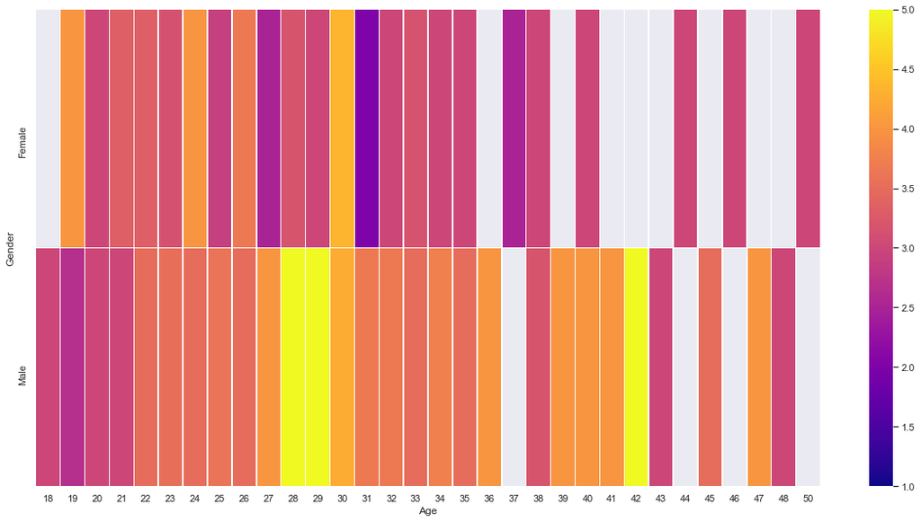

```python
df_hm =df.pivot_table(index = ['Gender'],columns ='Age',values ='Usage')
# Draw a heatmap
plt.figure(figsize = (20,10)) # To resize the plot
sns.heatmap(df_hm,  fmt="d", cmap='plasma', linewidths=.5, vmin=1)
plt.show()
```

- Male customers in age 28 and 29 are the most frequent users and a outlier on Age 42

**Usage Heatmap -Age + Gender + MaritialStatus**

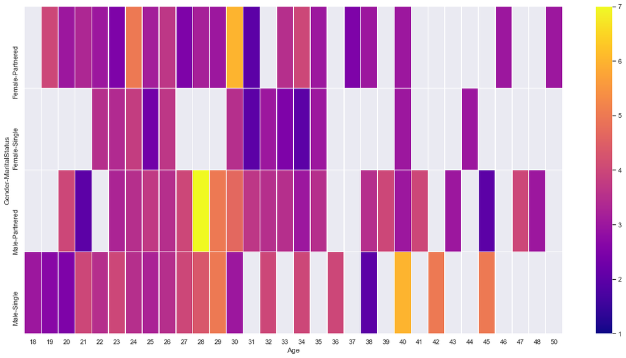

```python
df_hm =df.pivot_table(index = ['Gender','MaritalStatus'],columns ='Age',values ='Usage')
# Draw a heatmap
plt.figure(figsize = (20,10)) # To resize the plot
sns.heatmap(df_hm,  fmt="d", cmap='plasma', linewidths=.5, vmin=1)
plt.show()
```

- As found earlier Male customers in age 28 with maritial status as Partnered are the most frequent users

### Customer profile per product

#### Usage across Age per product

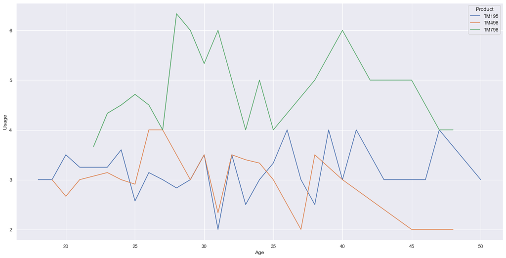

```python
plt.figure(figsize=(20,10))
sns.lineplot(x="Age", y="Usage", hue='Product',data=df,ci=0,color="RED")
plt.ylabel('Usage')
plt.xlabel('Age')
plt.show()
```

**Usage Heatmap -Age + Gender + MaritialStatus**

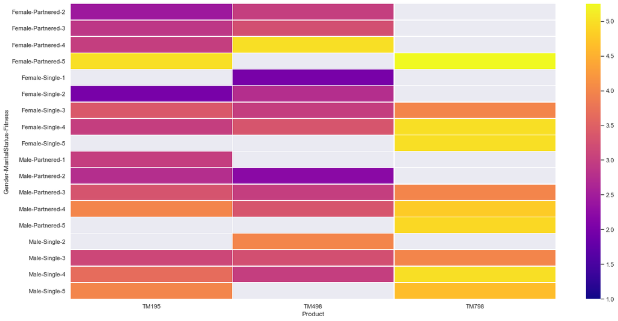

```python
df_hm =df.pivot_table(index = ['Gender','MaritalStatus','Fitness'],columns ='Product',values ='Usage')
# Draw a heatmap
plt.figure(figsize = (20,10)) # To resize the plot
sns.heatmap(df_hm,  fmt="d", cmap='plasma', linewidths=.5, vmin=1)
plt.show()
```

### Catplot to build customer profile per product

**Gender vs count per product**

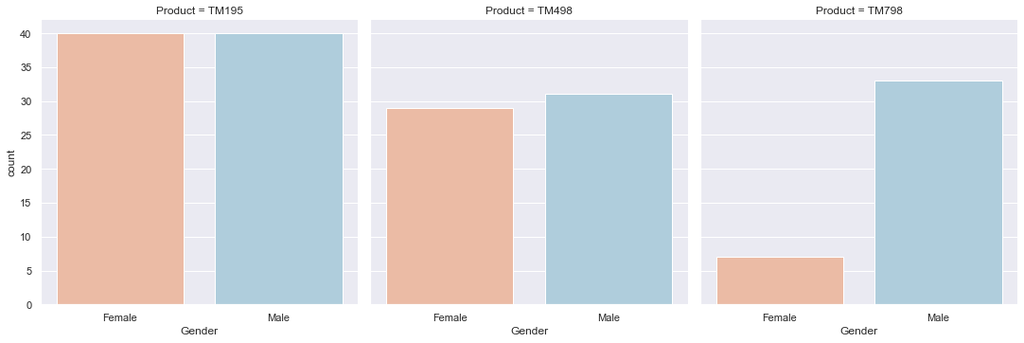

```python
sns.catplot(x='Gender',
             col='Product',
             data=df,
             col_wrap=3,
             kind="count",
             palette ='RdBu');
```

**Observations**

- Most customers have TM195 product. On Product, TM195 Equal distribution between male and female customers.
- TM498 has almost equal distribution between male and female customers.
- TM798 is the product which has lesser customers, and this product has more male customers.

**Age vs count per product**

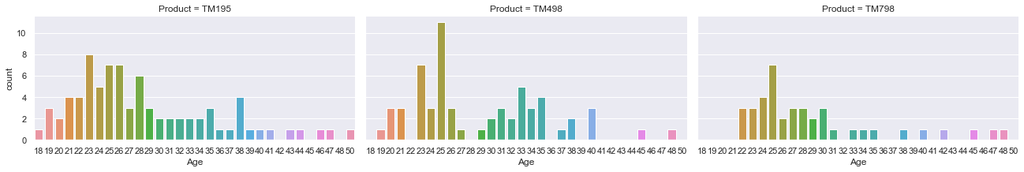

```python
sns.catplot(x='Age',
             col='Product',
             data=df,
             col_wrap=3,
             kind="count", height=3, aspect=2);
```

**Observations**

- TM195 - Widely used by customers in Age 23-28.
- TM498 - Widely used by customers in Age 23-25.
- TM798 - Widely used by customers in Age 22-30.

**Usage vs per product by Gender**

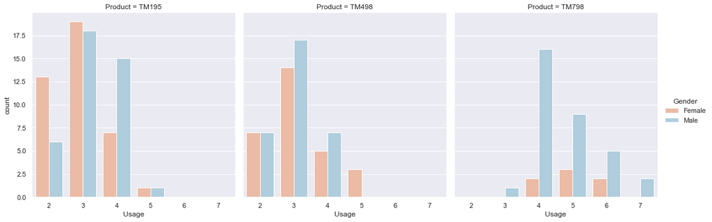

```python
sns.catplot(x='Usage',
             col='Product',
             data=df,
             hue='Gender',
             col_wrap=3,
             kind="count",
             palette ='RdBu');
```

**Observations**

- TM195 - Most Customer use 3-4 times per week.
- TM498 - Most Customer use 3 times per week.
- TM798 - Most Customer use more than 4 times per week, and more Male customer use it.

**Fitness Level vs per product**

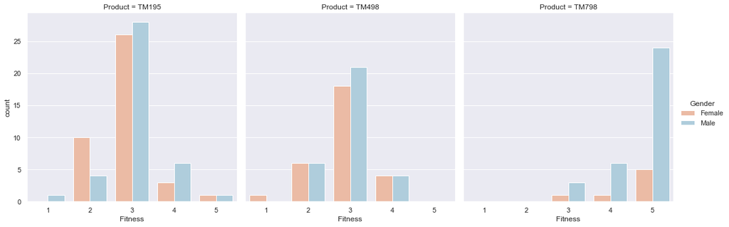

```python
sns.catplot(x='Fitness',
             col='Product',
             data=df,
             hue='Gender',
             col_wrap=3,
             kind="count",
             palette ='RdBu');
```

**Observations**

- TM195 - Most Customer have fitness level of 3
- TM498 - Most Customer have fitness level of 3
- TM798 - Most Customer have fitness level of 5

**MaritalStatus vs product**

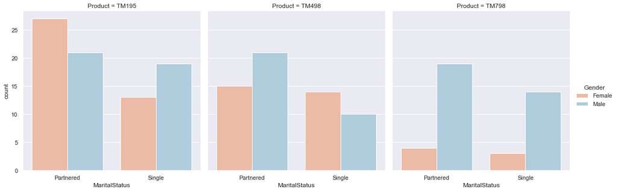

```python
sns.catplot(x='MaritalStatus',
             col='Product',
             data=df,
             hue='Gender',
             col_wrap=3,
             kind="count",
             palette ='RdBu');
```

**Observations**

- For all three products customers with Partnered Marital Status are more likely to use the product

**Education vs product**

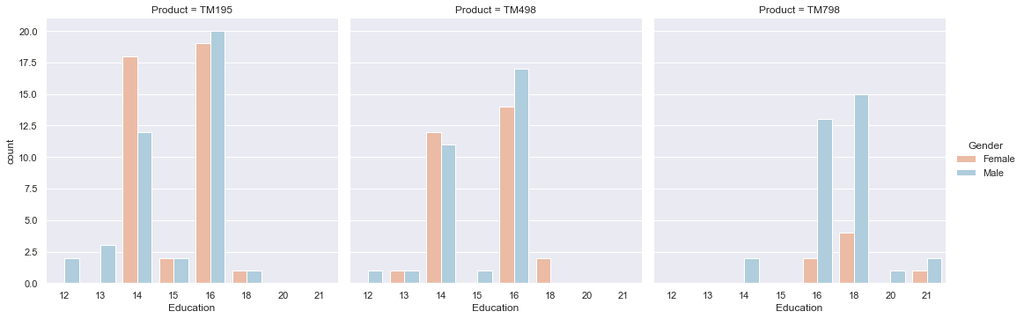

```python
sns.catplot(x='Education',
             col='Product',
             data=df,
             hue='Gender',
             col_wrap=3,
             kind="count",
             palette ='RdBu');
```

**Observations**

- TM195 - Most Customer have 14-16 years of education.
- TM498 - Most Customer have 14-16 years of education.
- TM798 - Customer with more than 16 years of education are more like to use it.

**Usage per week vs Income per Product**

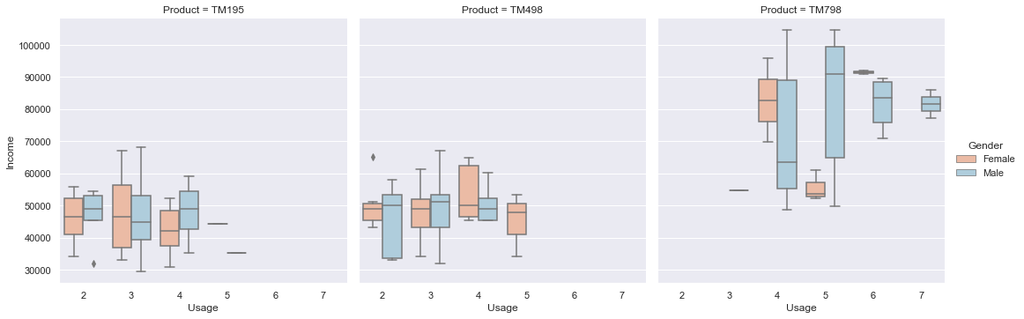

```python
sns.catplot(x='Usage',
            y='Income',
             col='Product',
             data=df,
             hue='Gender',
             col_wrap=3,
             kind="box",
             palette ='RdBu');
```

**Observations**

- TM195 - Customer with annual income between 40000 and 55000 are likely to use this product.
- TM498 - Customer with annual income below 60000 are likely to use this product.
- TM798 - Customer with annual income more than 60000 are the core users for this product.

**Usage vs Miles per week per Product**

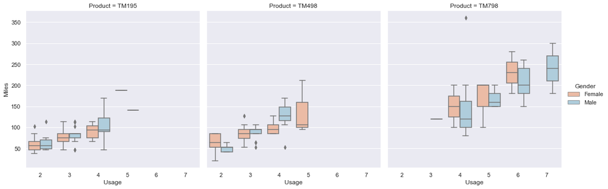

```python
sns.catplot(x='Usage',
            y='Miles',
             col='Product',
             data=df,
             hue='Gender',
             col_wrap=3,
             kind="box",
             palette ='RdBu');
```

**Observations**